# FigureYa121MethCGIcluster

Xiaofan Lu, Taojun Ye

2025-5-20

## 需求描述

用DNA甲基化数据做分型，画出这个图。

##Requirement description

Use DNA methylation data for typing and draw this graph.

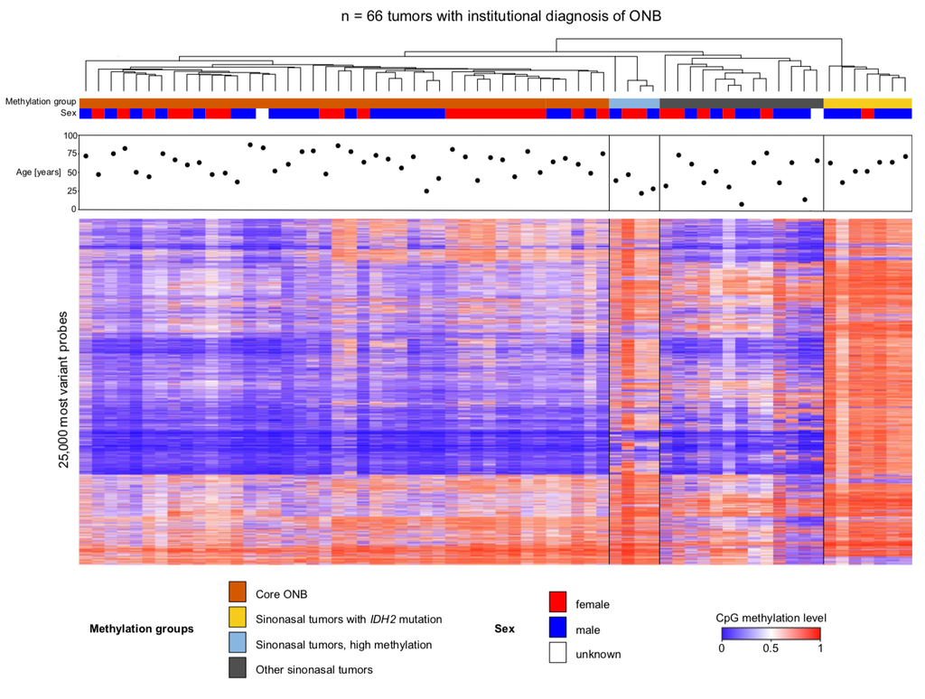

出自https://link.springer.com/article/10.1007%2Fs00401-018-1854-7

fromhttps://link.springer.com/article/10.1007%2Fs00401-018-1854-7

## 应用场景

DNA甲基化450k数据挑选出CpG位点，然后取高变异的探针，做无监督聚类分子分型。

可用于挖掘TCGA的DNA甲基化数据。

##Application scenarios

Select CpG sites from 450k DNA methylation data, and then use highly variable probes for unsupervised clustering molecular typing.

Can be used to mine DNA methylation data of TCGA.

## 环境设置

使用国内镜像安装包

##Environment settings

Use domestic image installation package

```r
options("repos"= c(CRAN="https://mirrors.tuna.tsinghua.edu.cn/CRAN/"))
options(BioC_mirror="http://mirrors.ustc.edu.cn/bioc/")
BiocManager::install("ChAMP")
```

加载包

library packages

```r
# 加载数据处理包
# Load data processing package
library(data.table)
# 加载表观基因组分析包
# Load epigenomic analysis package
library(ChAMP)
```

```
## locfit 1.5-9.12   2025-03-05
```

```
## Setting options('download.file.method.GEOquery'='auto')
```

```
## Setting options('GEOquery.inmemory.gpl'=FALSE)
```

```
## No methods found in package 'RSQLite' for request: 'dbListFields' when loading 'lumi'
```

[output not shown]

```r
# 加载聚类分析包
# Load cluster analysis package
library(ClassDiscovery)
```

```r
# 加载高级热图绘制包
# Load advanced heatmap plotting package
library(pheatmap)
# 加载基础绘图工具包
# Load basic plotting tools package
library(gplots)
# 加载复杂热图绘制包
# Load complex heatmap plotting package
library(ComplexHeatmap)
```

[output not shown]

```r
# 设置系统环境变量使报错信息显示为英文
# Set system environment variable to display error messages in English
Sys.setenv(LANGUAGE = "en")
# 全局选项设置：禁止字符串自动转换为因子类型
# Global option setting: Disable automatic conversion of strings to factors
options(stringsAsFactors = FALSE)
```

## 输入文件的准备

- HumanMethylation450.gz，甲基化由于数据庞大，这里选择了TCGA中样本量比较小的子宫肉瘤UCS为示例

数据于XENA平台下载，进入https://xenabrowser.net/datapages/，点击你感兴趣的癌症。此处以UCS为例，因此点击GDC TCGA Uterine Carcinosarcoma (UCS) (12 datasets)，点击DNA methylation下Illumina Human Methylation 450 (n=57) GDC Hub，https://xenabrowser.net/datapages/?dataset=TCGA.UCS.sampleMap%2FHumanMethylation450&host=https%3A%2F%2Ftcga.xenahubs.net&removeHub=https%3A%2F%2Fxena.treehouse.gi.ucsc.edu%3A443，点击download右侧的链接，下载得到HumanMethylation450.gz，解压到当前文件夹，无后缀名

Download the data from XENA platform and enter< https://xenabrowser.net/datapages/ >Click on the cancer that interests you. Taking UCS as an example, click on GDC TCGA Uterine Carcinosarcoma (UCS) (12 datasets), then click on Illumina Human Methylation 450 (n=57) GDC Hub under DNA methylation< https://xenabrowser.net/datapages/?dataset=TCGA.UCS.sampleMap%2FHumanMethylation450&host=https%3A%2F%2Ftcga.xenahubs.net&removeHub=https%3A%2F%2Fxena.treehouse.gi.ucsc.edu%3A443 >Click on the link on the right side of the download to obtain HumanMethylation450.gz. Extract it to the current folder without any extension

- easy_input_age.txt， Age is not necessary and is only used to mimic the example text. It can also be other data, and clinical information can be obtained by referring to FigureYa71ssGSEA.

```r
# 读取原始甲基化谱数据
# Read original methylation profile data
orgmeth <- fread("TCGA.UCS.sampleMap_HumanMethylation450.gz")  # 使用fast read快速读取大文件（适用于高效处理大数据）
# Use fast read to quickly read large files (suitable for efficient processing of big data)

# 数据格式转换与预处理
# Data format conversion and preprocessing
orgmeth <- as.data.frame(orgmeth); rownames(orgmeth) <- orgmeth[,1]; orgmeth <- orgmeth[,-1]
# 将数据转换为数据框格式，设置第一列为行名，并删除第一列原始数据
# Convert data to data frame format, set the first column as row names, and delete the first column of original data

# 查看数据前3行3列的样本（用于初步检查数据结构）
# View the first 3 rows and 3 columns of the data (for initial data structure inspection)
orgmeth[1:3,1:3]
```

```
##            TCGA-N6-A4VF-01 TCGA-N7-A59B-01 TCGA-N7-A4Y0-01
## cg13332474          0.1521          0.0442          0.0994
## cg00651829          0.0209          0.0185          0.0189
## cg17027195          0.0362          0.0567          0.0441
```

```r
# ----------------------- 模拟年龄数据（注释中说明为模拟数据，实际使用时可取消注释） -----------------------
# ----------------------- Simulate age data (note that it is simulated data, uncomment when actually using) -----------------------
# 生成模拟年龄数据（在ncol(orgmeth)个样本中，生成30-60岁的随机整数年龄）
# Generate simulated age data (generate random integer ages between 30-60 for ncol(orgmeth) samples)
#Sinfo <- data.frame(age = floor(runif(ncol(orgmeth),min = 30,max = 60)),row.names = colnames(orgmeth),stringsAsFactors = F)
# 将模拟年龄数据写入文本文件（便于后续读取）
# Write simulated age data to a text file (for subsequent reading)
#write.table(Sinfo, "easy_input_age.txt", sep = "\t", quote = F)


# 读取实际年龄数据文件（从文本文件中加载样本年龄信息）
# Read actual age data file (load sample age information from text file)
Sinfo <- read.table("easy_input_age.txt", header = T, row.names = 1)
# 查看年龄数据的前几行（检查数据读取是否正确）
# View the first few rows of age data (check if data reading is correct)
head(Sinfo)
```

```
##                 age
## TCGA-N6-A4VF-01  46
## TCGA-N7-A59B-01  49
## TCGA-N7-A4Y0-01  38
## TCGA-QN-A5NN-01  37
## TCGA-N6-A4VD-01  54
## TCGA-N8-A4PN-01  49
```

## 挑选出CpG位点

利用champ包做探针过滤，探针主要包括CpG、XY染色体和SNPs，我们只保留CpG位点。

**题外话：**champ包功能强大，尤其是在差异甲基化功能富集上，感兴趣的小伙伴可以自行学习

##Select CpG sites

Using the champ package for probe filtering, the probes mainly include CpG, XY chromosomes, and SNPs, while we only retain CpG sites.

**Off topic: The Champ package has powerful features, especially in the enrichment of differential methylation functions. Interested friends can learn it on their own

```r
# 使用champ.filter函数对甲基化数据进行探针过滤
# Filter methylation probes using champ.filter function
myFilter <- champ.filter(
  beta           = orgmeth,         # 输入的beta值矩阵（甲基化水平矩阵）
                                 # Input beta value matrix (methylation level matrix)
  pd             = NULL,            # 样本信息数据框（因仅进行探针过滤，无需样本信息）
                                 # Sample information data frame (not needed for probe filtering)
  # 以下过滤参数基于参考文献46设置，主要针对CpG、SNP及性染色体探针
  # The following filtering parameters are based on reference 46, targeting CpG, SNP, and sex chromosome probes
  autoimpute     = F,               # 不进行缺失值填补（保持原始数据）
                                 # Do not impute missing values (keep original data)
  filterDetP     = F,               # 不基于检测p值过滤探针（保留所有检测到的探针）
                                 # Do not filter probes by detection p-value
  fixOutlier     = F,               # 不修正离群值（因缺少样本信息，设置为T会报错）
                                 # Do not fix outliers (setting T will cause error without sample info)
  filterMultiHit = T,               # 过滤多重比对探针（移除可能比对到多个基因组位置的探针）
                                 # Filter probes with multiple genomic alignments
  filterNoCG     = T,               # 仅保留CpG位点探针（排除非CpG甲基化位点）
                                 # Retain only CpG site probes
  filterSNPs     = T,               # 过滤含有SNP的探针（避免SNP干扰甲基化检测）
                                 # Filter probes overlapping with SNPs
  filterXY       = T,               # 过滤性染色体上的探针（排除性别相关的甲基化差异）
                                 # Filter probes on sex chromosomes (exclude sex-related differences)
  arraytype      = "450K"           # 指定芯片类型为Illumina 450K
                                 # Specify microarray type as Illumina 450K
)
```

```
## [===========================]
```

```
## [<<<< ChAMP.FILTER START >>>>>]
```

[output not shown]

[output not shown]

[output not shown]

```
##
##
## [ Section 1:  Check Input Start ]
```

```
##   You have inputed beta for Analysis.
```

```
##
##   Parameter filterBeads is TRUE, checking if beadcount in accord with Data Matrix...
```

```
##     !!! Parameter beadcount is not found, filterBeads is reset FALSE now.
```

```
##
##   Checking Finished :filterMultiHit,filterSNPs,filterNoCG,filterXY would be done on beta.
```

```
##   You also provided :detP .
```

```
## [ Section 1: Check Input Done ]
```

```
##
##
## [ Section 2: Filtering Start >>
```

```
##
##   Filtering NoCG Start
```

```
##     Only Keep CpGs, removing 3156 probes from the analysis.
```

```
##
##   Filtering SNPs Start
```

```
##     Using general 450K SNP list for filtering.
```

```
##     Filtering probes with SNPs as identified in Zhou's Nucleic Acids Research Paper 2016.
```

```
##     Removing 59901 probes from the analysis.
```

```
##
##   Filtering MultiHit Start
```

```
##     Filtering probes that align to multiple locations as identified in Nordlund et al
```

```
##     Removing 11 probes from the analysis.
```

```
##
##   Filtering XY Start
```

```
##     Filtering probes located on X,Y chromosome, removing 10028 probes from the analysis.
```

```
## [ Section 2: Filtering Done ]
```

```
##
##  All filterings are Done, now you have 412481 probes and 57 samples.
```

```
## [<<<<< ChAMP.FILTER END >>>>>>]
```

```
## [===========================]
```

```
## [You may want to process champ.QC() next.]
```

```r
# 查看过滤后数据的维度（行数=探针数，列数=样本数）
# Check dimensions of filtered data (rows = probes, columns = samples)
dim(myFilter$beta)
```

```
## [1] 412481     57
```

```r
### 挑选感兴趣区域（启动子CpG Island） ###
### Select regions of interest (promoter CpG Islands) ###

# 如果需要筛选特定基因组区域的探针，可加载注释文件并获取探针注释信息
# If you need to filter probes in specific genomic regions, load annotation files
library(IlluminaHumanMethylation450kanno.ilmn12.hg19)  # 加载450K芯片注释包
                                 # Load annotation package for Illumina 450K array
data("IlluminaHumanMethylation450kanno.ilmn12.hg19")    # 加载注释数据
                                 # Load annotation data
anno <- getAnnotation(IlluminaHumanMethylation450kanno.ilmn12.hg19)  # 获取注释信息
                                 # Retrieve probe annotation information

# 筛选位于启动子区域的CpG岛探针
# Select probes located in promoter CpG islands
prompb <- rownames(anno[
  which(
    anno$Relation_to_Island == "Island" &    # 探针必须位于CpG岛区域
                                  # Probes must be within CpG islands
    grepl("TSS", anno$UCSC_RefGene_Group)     # 探针必须与转录起始位点(TSS)相关
                                  # Probes must be associated with transcription start sites (TSS)
  ),
])

# 从过滤后的甲基化数据中提取感兴趣的探针数据
# Extract data of selected probes from filtered methylation data
indata <- myFilter$beta[prompb, ]
```

## 取高变异的探针（此处取2500个）

##Take probes with high variability (here take 2500 probes)

```r
k <- 2500  # 选择变异程度最高的前k个探针（此处k设为2500）
          # Select the top k probes with highest variability (k=2500 here)

# 计算每个探针在所有样本中的标准差（衡量甲基化水平变异程度）
# Calculate standard deviation for each probe across all samples (measure of methylation variability)
var <- apply(indata, 1, sd)

# 对标准差从大到小排序（降序排列）
# Sort standard deviations in descending order
var <- sort(var, decreasing = T)

# 提取变异程度最高的前k个探针的甲基化数据
# Extract methylation data for the top k probes with highest variability
topcgimeth <- indata[names(var[1:k]), ]

# 查看前3行3列数据（检查提取结果是否正确）
# View first 3 rows and 3 columns of the extracted data (check results)
topcgimeth[1:3, 1:3]
```

```
##            TCGA-N6-A4VF-01 TCGA-N7-A59B-01 TCGA-N7-A4Y0-01
## cg21576698          0.0359          0.9657          0.0397
## cg16642284          0.7941          0.9212          0.9056
## cg19439810          0.0495          0.9478          0.0486
```

## 无监督分子分型

##Unsupervised molecular subtyping

```r
# 对样本进行层次聚类（基于高变异性CpG岛探针的甲基化数据）
# Hierarchical clustering of samples based on methylation data of highly variable CpG island probes
hcg <- hclust(
  distanceMatrix(t(topcgimeth), "euclidean"),  # 计算样本间欧氏距离矩阵（需转置数据）
                                              # Calculate Euclidean distance matrix between samples (transpose data)
  "ward.D"                                    # 使用Ward方差最小化法进行聚类（使类内方差最小）
                                              # Use Ward's method for hierarchical clustering (minimize within-cluster variance)
)

# 手动触发垃圾回收（释放内存，尤其在处理大型数据集后）
# Manually trigger garbage collection to free up memory (especially after processing large datasets)
gc()
```

```
##             used   (Mb) gc trigger   (Mb) limit (Mb)  max used   (Mb)
## Ncells  19474249 1040.1   28193982 1505.8         NA  25785999 1377.2
## Vcells 146887294 1120.7  227482464 1735.6      32768 189502049 1445.8
```

```r
# 对探针进行层次聚类（基于甲基化模式的相似性）
# Hierarchical clustering of probes based on similarity of methylation patterns
hcs <- hclust(
  distanceMatrix(topcgimeth, "euclidean"),  # 计算探针间欧氏距离矩阵
                                           # Calculate Euclidean distance matrix between probes
  "ward.D"                                 # 使用Ward方法进行聚类
                                           # Use Ward's method for clustering
)

# 将样本分为3个聚类组（可根据实际需求调整聚类数量）
# Divide samples into 3 clusters (adjust the number of clusters according to requirements)
group <- cutree(hcs, 3)

# 将聚类结果转换为"C1"、"C2"、"C3"格式的组标签
# Convert cluster numbers to group labels in the format of "C1", "C2", "C3"
group <- paste0("C", as.character(group))
names(group) <- colnames(topcgimeth)  # 将组标签与样本名称关联
                                      # Associate group labels with sample names
```

## 开始画图

这里提供两种画法：

- 画法一用pheatmap，简单易用，如果不画age，这个就够了。
- 画法二用complexheatmap，复现原图。

### 画法一：pheatmap

##Start drawing

Here are two painting methods provided:

-Using pheatmap for drawing is simple and easy to use. If you don’t draw age, this is enough. -Use complexheatmap for drawing method two to reproduce the original image.

###Drawing Method 1: Pheatmap

```
## `use_raster` is automatically set to TRUE for a matrix with more than
## 2000 rows. You can control `use_raster` argument by explicitly setting
## TRUE/FALSE to it.
##
## Set `ht_opt$message = FALSE` to turn off this message.
```

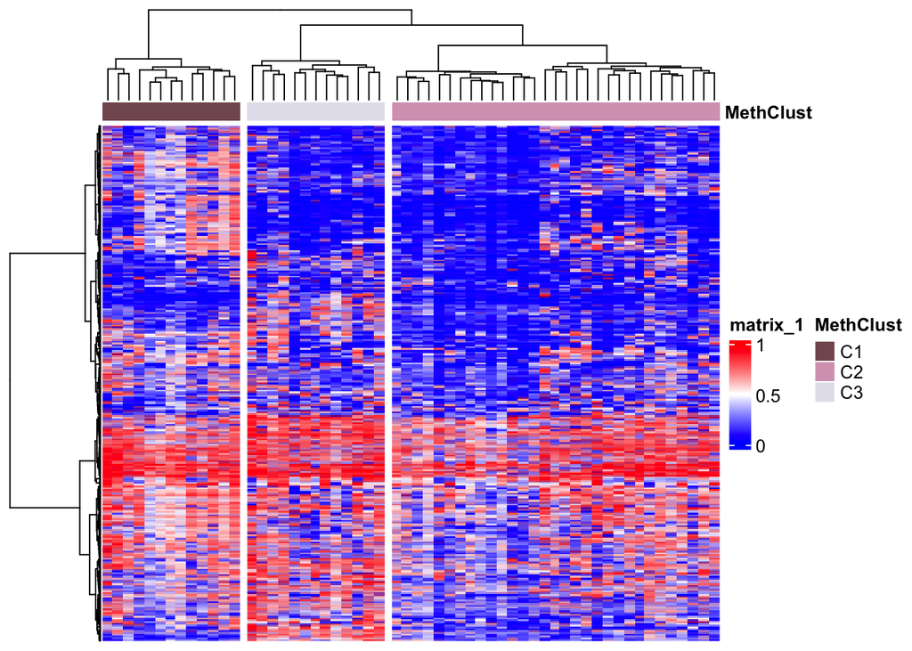

[figure not shown]

```r
### 设置颜色 ###
### Set Colors ###
blue   <- "#5bc0eb"  # 定义蓝色（用于聚类C1）
                    # Define blue color (for cluster C1)
yellow <- "#fde74c"  # 定义黄色（用于聚类C3）
                    # Define yellow color (for cluster C3)
green  <- "#9bc53d"  # 定义绿色（用于聚类C2）
                    # Define green color (for cluster C2)


# 绘制甲基化聚类热图（可参考FigureYa91cluster_heatmap）
# Draw methylation clustering heatmap (refer to FigureYa91cluster_heatmap)
annCol <- data.frame(
  MethClust = group,  # 样本聚类分组信息
                    # Sample clustering group information
  row.names = names(group),  # 设置行名为样本名称
                          # Set row names as sample names
  stringsAsFactors = F  # 禁止自动转换字符串为因子
                     # Disable automatic conversion of strings to factors
)

# 定义注释列的颜色映射（为不同聚类组指定颜色）
# Define color mapping for annotation columns (assign colors to different clusters)
annColors <- list(
  "Methylation group" = c(
    "C1" = blue,    # 聚类C1映射为蓝色
                   # Cluster C1 mapped to blue
    "C2" = green,   # 聚类C2映射为绿色
                   # Cluster C2 mapped to green
    "C3" = yellow   # 聚类C3映射为黄色
                   # Cluster C3 mapped to yellow
  )
)

# 使用pheatmap绘制热图
# Draw heatmap using pheatmap
pheatmap(
  topcgimeth,  # 输入数据：高变异性CpG岛探针的甲基化数据
             # Input data: Methylation data of highly variable CpG island probes
  color = bluered(64),  # 使用蓝红渐变调色板（64个颜色梯度）
                     # Use blue-red gradient color palette (64 color levels)
  cluster_rows = hcg,  # 使用预先计算的探针层次聚类结果
                    # Use precomputed hierarchical clustering for rows (probes)
  cluster_cols = hcs,  # 使用预先计算的样本层次聚类结果
                    # Use precomputed hierarchical clustering for columns (samples)
  cutree_cols = 3,  # 将样本列聚类分为3组（与前面的cutree结果一致）
                  # Cut column clustering into 3 groups (consistent with previous cutree result)
  annotation_col = annCol,  # 添加样本聚类注释列
                          # Add sample cluster annotation column
  annotation_colors = annColors,  # 指定注释列的颜色映射
                               # Specify colors for annotation columns
  show_rownames = F,  # 不显示行名（探针ID）
                    # Do not show row names (probe IDs)
  show_colnames = F,  # 不显示列名（样本ID）
                    # Do not show column names (sample IDs)
  filename = "methylation_cgi_clustering_pheatmap.pdf"  # 保存热图为PDF文件
                                                        # Save heatmap as PDF file
)
```

### 画法二：complexheatmap

###Drawing Method 2: Complex Heatmap

```r
# 创建顶部注释（用于ComplexHeatmap可视化）
# Create top annotation for ComplexHeatmap visualization
column_ha <- HeatmapAnnotation(
  df = data.frame(
    MethClust = as.character(group[colnames(topcgimeth)]),  # 甲基化聚类分组注释
                                                           # Methylation cluster annotation
    row.names = colnames(topcgimeth)  # 设置行名为样本名称
                                   # Set row names as sample names
  ),
  col = list(
    "MethClust" = c("C1" = "steelblue", "C2" = "red", "C3" = "grey40")  # 聚类分组颜色映射
                                                                           # Color mapping for clusters
  ),
  age = anno_points(
    as.numeric(Sinfo$age),  # 年龄数值注释（以散点形式展示）
                          # Age numerical annotation (displayed as points)
    axis_param = list(
      side = "left",  # 坐标轴显示在左侧
                     # Axis displayed on the left
      at = c(30, 40, 50),  # 坐标轴刻度位置
                         # Axis tick positions
      labels = c("30", "40", "50")  # 坐标轴刻度标签
                                 # Axis tick labels
    )
  ),
  height = unit(2.7, "cm"),  # 注释区域高度
                           # Height of annotation area
  show_annotation_name = T  # 显示注释名称
                          # Show annotation names
)

# 创建ComplexHeatmap对象
# Create ComplexHeatmap object
hm <- Heatmap(
  topcgimeth,  # 输入数据：高变异性CpG岛探针的甲基化数据
             # Input data: Methylation data of highly variable CpG island probes
  name = "CpG methylation level",  # 热图标题（颜色条名称）
                                 # Heatmap title (color bar name)
  col = bluered(64),  # 使用蓝红渐变调色板（64个颜色梯度）
                     # Use blue-red gradient color palette (64 color levels)
  cluster_columns = hcs,  # 使用预计算的样本层次聚类结果
                       # Use precomputed hierarchical clustering for columns (samples)
  cluster_rows = hcg,  # 使用预计算的探针层次聚类结果
                    # Use precomputed hierarchical clustering for rows (probes)
  show_column_names = F,  # 不显示列名（样本ID）
                       # Do not show column names (sample IDs)
  show_row_names = F,  # 不显示行名（探针ID）
                    # Do not show row names (probe IDs)
  top_annotation = column_ha  # 添加顶部注释
                           # Add top annotation
)
```

```
## `use_raster` is automatically set to TRUE for a matrix with more than
## 2000 rows. You can control `use_raster` argument by explicitly setting
## TRUE/FALSE to it.
##
## Set `ht_opt$message = FALSE` to turn off this message.
```

```r
# 保存热图为PDF文件
# Save heatmap as PDF file
pdf("methylation_cgi_clustering_complexheatmap.pdf", width = 8, height = 7)
draw(hm)
invisible(dev.off())
```

[figure not shown]